# PreRequisite

Sujatha Jagannathan

February 6, 2019

## R Set up

The goal of this pre-class assignment is to make sure that you:

1. Install R
2. Install Rstudio
3. Install tidyverse and rmarkdown packages
4. Create a new Rmarkdown document (lastname-prereq.rmd) - more about this later
5. Knit the .Rmd document and submit the resulting .html file as your pre-class assignment

Doing all of the above is *necessary* to hit the ground running in your first class.

#### A) Install R

Download the latest release of R from The Comprehensive R Archive Network, or [CRAN](https://cran.rstudio.com/), for short. Choose the right version for your operating system and follow the directions.

#### B) Install Rstudio

Rstudio is an Integrated Development Environment (IDE) for R. Download the free version of RStudio Desktop from this [link](https://www.rstudio.com/products/rstudio/download/#download) by choosing the appropriate installer file for your operating system.

#### C) Install tidyverse and rmarkdown

`*`**Important**`*` Before you do this step, you need to familiarize yourself with the Rstudio window. Now would be a good time to peruse this [tutorial](https://swcarpentry.github.io/r-novice-gapminder/01-rstudio-intro/) to get a working familiarity of Rstudio.

Once you have done that, go ahead and click on the Rstudio icon to open a new Rstudio window. It usually looks like this:

[figure not shown]

The console is where you type your code and usually the output appears right there. If you are generating a plot, it would show in the bottom right “plots” area. The following image shows a minimal “parts list” of the Rstudio window.

[figure not shown]

Now that you know where the code goes, type the following lines into the console:

```r
r = getOption("repos")
r["CRAN"] = "http://cran.us.r-project.org"
options(repos = r)
install.packages("tidyverse")
install.packages("rmarkdown")
```

#### D) Create a new Rmarkdown document (lastname-prereq.rmd)

Now that your R environment is set up (or should be set up), let’s check that this is the case.

1. Click on: File > New File > R Markdown

[figure not shown]

2. Enter a title (yourlastname-prereq.rmd) and keep the output format to html
3. You should be looking at a file like this

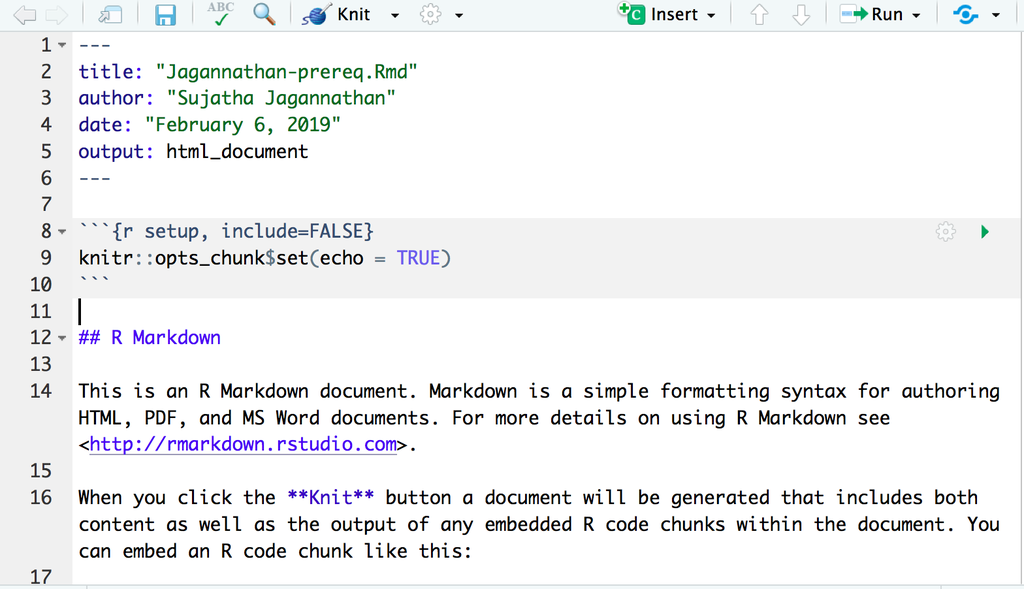

4. Within the first code chunk (the grey boxed area between lines 8-10), enter the following as new lines. Change the option “include=FALSE” to “include=TRUE”.

```r
library("tidyverse")
library("rmarkdown")
sessionInfo()
```

Like so.

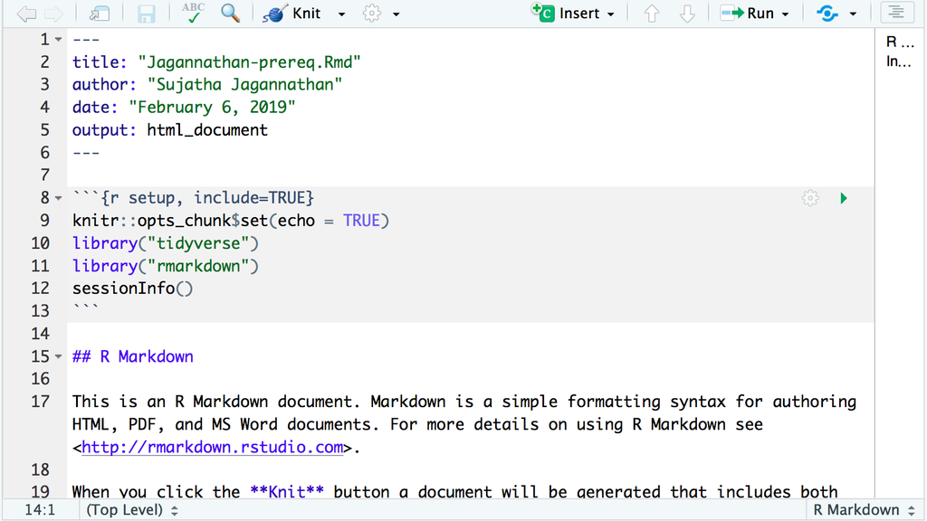

Note: Feel free to delete everything below the first code chunk.

5. Save the document as yourlastname-prereq.Rmd

#### E) Knit the .Rmd document and submit the resulting .html file as your pre-class assignment

This is the simple stuff. Click on the “knit” button.

[figure not shown]

Upload the html output (which should show up in whichever folder you keep the .Rmd file) to Canvas. This is your preclass assignment.

## Acknowledgements

I have borrowed content heavily from the [!Rstudio website](https://www.rstudio.com/products/rstudio/features/).